# Vaccine allocation project results

GMB

2022-06-01

# 1 Introduction

This document brings together results from multiple model runs. It is intended to be re-run as the model is updated.

NOTE: The setting for this run is: SLE

**Focus questions:**

- What impact will the existing vaccination plan have on morbidity and mortality?
- What impact can be achieved under different levels of vaccine coverage?
- What are the potential benefits of expanding the immunisation schedule to include children?

**Overarching assumptions**

Unless otherwise specified, key model parameters in this run are:

| Variable | Value | Source |
| --- | --- | --- |
| Circulating strain | omicron |  |
| Length of model run | 52 |  |
| Current vaccine coverage | dose one: 26%; dose two: 18% | John Hopkins COVID-19 vaccination data |
| Current vaccine coverage target | 51.6% | Government target in COVAX documentation May 2021 |
| Proportion of population willing to be vaccinated | 88% | Survey estimating vaccine acceptance in January 2021 (Solis et al., 2021) |
| Daily capacity for vaccination (doses) | 11075 | Slightly lower than the pilot vaccination campaign October-November 2021 |
| Anticipated type of future vaccine doses | Johnson & Johnson | The Government of Sierra Leone has demonstrated a strong preference for this vaccine, negotiating with major donors, such as the Government of Italy, to change their donations of double-dose vaccines … |
| Waning of VE against acquisition | TRUE |  |
| Waning of VE against severe disease | FALSE |  |
| Waning of infection-derived immunity against acquisition | TRUE |  |
| Waning of infection-derived immunity against severe outcomes | Not yet included |  |
| YLL discounting | 0 |  |

**Other assumptions/limitations:**

- Linear roll-out of vaccines (Lowy Institute report and trends in the ACT do not support this)
- Vaccine effectiveness estimates last updated on the 14th of April 2022 from WHO live systematic review (https://view-hub.org/covid-19/effectiveness-studies)

**Next steps for noting:**

- update of infection- and vaccine-derived immunity
- sensitivity analysis
  - turning on/off waning of vaccine-derived immunity
  - simulating outbreaks of different strains
  - experimenting with different age-prioritisation strategies
  - other?

# 2 Impact of current program targets

Roll out of current program target (51.6% coverage) during or prior to an outbreak:

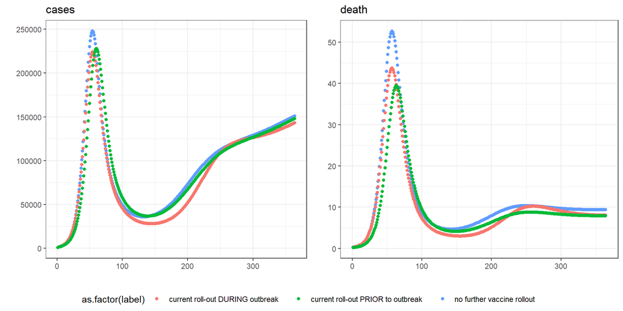

Absolute difference in outcomes (compared to no further vaccine roll-out)

| scenario | death | hosp | severe_disease | YLL | cases |
| --- | --- | --- | --- | --- | --- |
| current roll-out DURING outbreak | 646 | 24,176 | 7,802 | 6,851 | 2,878,902 |
| current roll-out PRIOR to outbreak | 760 | 30,033 | 9,741 | 8,314 | 1,043,675 |

Relative difference in outcomes

| scenario | death | hosp | severe_disease | YLL | cases |
| --- | --- | --- | --- | --- | --- |
| current roll-out DURING outbreak | 15.42 | 9.92 | 14.32 | 12.93 | 8.46 |
| current roll-out PRIOR to outbreak | 18.12 | 12.32 | 17.88 | 15.69 | 3.07 |

# 3 Varying levels of coverage

## 3.1 Using current age-specific eligiblity

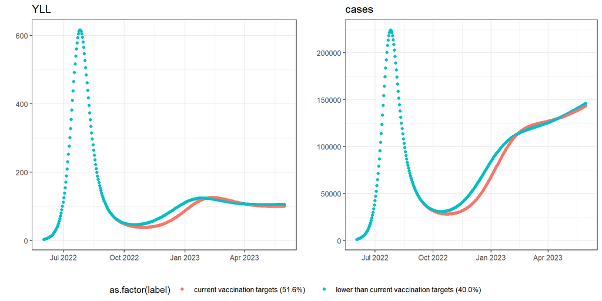

Absolute difference in outcomes (compared to current vaccine targets)

| scenario | macro_age_group | death | hosp | severe_disease | YLL | cases |
| --- | --- | --- | --- | --- | --- | --- |
| lower than current vaccination targets (40.0%) | adults | -178 | -6,399 | -2,179 | -1,861 | -859,379 |
| lower than current vaccination targets (40.0%) | children | -1 | -616 | -9 | -66 | -309,610 |
| lower than current vaccination targets (40.0%) | net | -179 | -7,015 | -2,188 | -1,926 | -1,168,989 |

Relative difference in outcomes (%)

| scenario | macro_age_group | death | hosp | severe_disease | YLL | cases |
| --- | --- | --- | --- | --- | --- | --- |
| lower than current vaccination targets (40.0%) | adults | -5.24 | -4.66 | -4.79 | -4.96 | -4.81 |
| lower than current vaccination targets (40.0%) | children | -0.76 | -0.75 | -0.73 | -0.76 | -2.33 |
| lower than current vaccination targets (40.0%) | net | -5.06 | -3.20 | -4.69 | -4.18 | -3.75 |

## 3.2 Expanding eligibility to children (DURING an outbreak)

### 3.2.1 Run current vaccine campaign, then expand to children

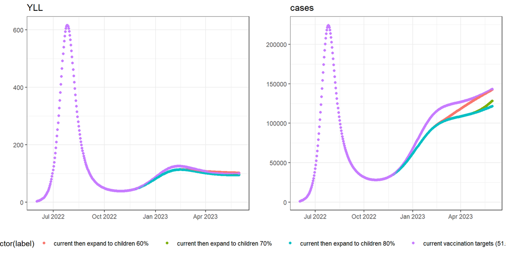

Absolute difference in outcomes (compared to current vaccine targets)

| scenario | macro_age_group | death | hosp | severe_disease | YLL | cases |
| --- | --- | --- | --- | --- | --- | --- |
| current then expand to children 60% | adults | 40 | 854 | 351 | 331 | 318,643 |
| current then expand to children 60% | children | 6 | 3,582 | 58 | 347 | 1,189,035 |
| current then expand to children 60% | net | 46 | 4,437 | 409 | 679 | 1,507,678 |
| current then expand to children 70% | adults | 74 | 1,655 | 666 | 623 | 563,982 |
| current then expand to children 70% | children | 10 | 6,000 | 97 | 583 | 2,013,700 |
| current then expand to children 70% | net | 84 | 7,655 | 763 | 1,206 | 2,577,682 |
| current then expand to children 80% | adults | 76 | 1,708 | 687 | 641 | 577,760 |
| current then expand to children 80% | children | 10 | 6,257 | 101 | 608 | 2,095,631 |
| current then expand to children 80% | net | 87 | 7,966 | 788 | 1,249 | 2,673,391 |

Relative difference in outcomes (%)

| scenario | macro_age_group | death | hosp | severe_disease | YLL | cases |
| --- | --- | --- | --- | --- | --- | --- |
| current then expand to children 60% | adults | 1.18 | 0.62 | 0.77 | 0.88 | 1.78 |
| current then expand to children 60% | children | 4.18 | 4.36 | 4.85 | 4.02 | 8.95 |
| current then expand to children 60% | net | 1.30 | 2.02 | 0.88 | 1.47 | 4.84 |
| current then expand to children 70% | adults | 2.18 | 1.21 | 1.47 | 1.66 | 3.16 |
| current then expand to children 70% | children | 7.01 | 7.30 | 8.10 | 6.75 | 15.16 |
| current then expand to children 70% | net | 2.37 | 3.49 | 1.64 | 2.61 | 8.28 |
| current then expand to children 80% | adults | 2.24 | 1.24 | 1.51 | 1.71 | 3.24 |
| current then expand to children 80% | children | 7.31 | 7.61 | 8.45 | 7.04 | 15.78 |
| current then expand to children 80% | net | 2.44 | 3.63 | 1.69 | 2.71 | 8.59 |

### 3.2.2 Expand to children now

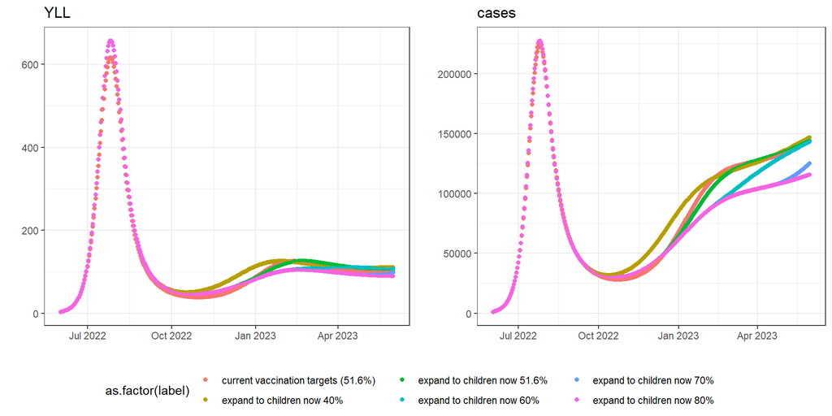

Absolute difference in outcomes (compared to current vaccine targets)

| scenario | macro_age_group | death | hosp | severe_disease | YLL | cases |
| --- | --- | --- | --- | --- | --- | --- |
| expand to children now 40% | adults | -424 | -15,222 | -5,195 | -4,447 | -1,370,564 |
| expand to children now 40% | children | 4 | 2,426 | 42 | 222 | -60,884 |
| expand to children now 40% | net | -420 | -12,797 | -5,153 | -4,225 | -1,431,448 |
| expand to children now 51.6% | adults | -283 | -10,461 | -3,546 | -3,023 | -535,768 |
| expand to children now 51.6% | children | 8 | 4,991 | 83 | 475 | 666,138 |
| expand to children now 51.6% | net | -275 | -5,470 | -3,463 | -2,549 | 130,369 |
| expand to children now 60% | adults | -178 | -7,266 | -2,399 | -2,013 | 208,005 |
| expand to children now 60% | children | 11 | 6,708 | 110 | 645 | 1,351,233 |
| expand to children now 60% | net | -167 | -558 | -2,289 | -1,368 | 1,559,238 |
| expand to children now 70% | adults | -77 | -4,180 | -1,285 | -1,032 | 964,139 |
| expand to children now 70% | children | 14 | 8,475 | 137 | 823 | 2,048,576 |
| expand to children now 70% | net | -63 | 4,296 | -1,148 | -210 | 3,012,715 |
| expand to children now 80% | adults | -68 | -3,872 | -1,178 | -940 | 1,033,753 |
| expand to children now 80% | children | 14 | 8,659 | 140 | 841 | 2,116,222 |
| expand to children now 80% | net | -54 | 4,787 | -1,038 | -99 | 3,149,976 |

Relative difference in outcomes (%)

| scenario | macro_age_group | death | hosp | severe_disease | YLL | cases |
| --- | --- | --- | --- | --- | --- | --- |
| expand to children now 40% | adults | -12.45 | -11.09 | -11.42 | -11.86 | -7.68 |
| expand to children now 40% | children | 2.75 | 2.95 | 3.51 | 2.57 | -0.46 |
| expand to children now 40% | net | -11.84 | -5.83 | -11.04 | -9.16 | -4.60 |
| expand to children now 51.6% | adults | -8.31 | -7.62 | -7.80 | -8.06 | -3.00 |
| expand to children now 51.6% | children | 5.76 | 6.07 | 6.92 | 5.49 | 5.02 |
| expand to children now 51.6% | net | -7.76 | -2.49 | -7.42 | -5.53 | 0.42 |
| expand to children now 60% | adults | -5.24 | -5.29 | -5.28 | -5.37 | 1.17 |
| expand to children now 60% | children | 7.79 | 8.16 | 9.18 | 7.47 | 10.17 |
| expand to children now 60% | net | -4.72 | -0.25 | -4.90 | -2.96 | 5.01 |
| expand to children now 70% | adults | -2.27 | -3.04 | -2.83 | -2.75 | 5.40 |
| expand to children now 70% | children | 9.89 | 10.31 | 11.47 | 9.52 | 15.43 |
| expand to children now 70% | net | -1.78 | 1.96 | -2.46 | -0.45 | 9.68 |
| expand to children now 80% | adults | -2.00 | -2.82 | -2.59 | -2.51 | 5.79 |
| expand to children now 80% | children | 10.11 | 10.53 | 11.71 | 9.73 | 15.94 |
| expand to children now 80% | net | -1.52 | 2.18 | -2.22 | -0.21 | 10.12 |

## 3.3 Expanding eligibility to children (PRIOR TO an outbreak)

Note: If waning immunity against severe outcomes ON, this looks like a bad idea.

### 3.3.1 Run current vaccine campaign, then expand to children

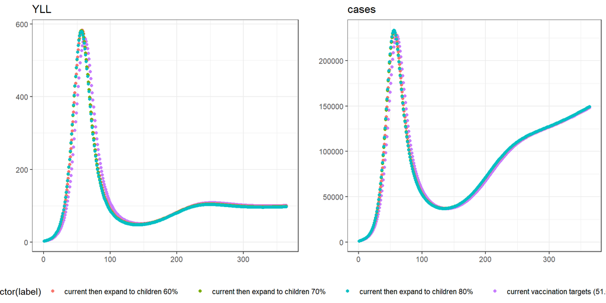

Absolute difference in outcomes (compared to current vaccine targets)

| scenario | macro_age_group | death | hosp | severe_disease | YLL | cases |
| --- | --- | --- | --- | --- | --- | --- |
| current then expand to children 60% | adults | -53 | -1,767 | -618 | -539 | -453,776 |
| current then expand to children 60% | children | 11 | 6,724 | 112 | 637 | 30,744 |
| current then expand to children 60% | net | -42 | 4,958 | -506 | 98 | -423,031 |
| current then expand to children 70% | adults | -63 | -2,104 | -736 | -641 | -535,863 |
| current then expand to children 70% | children | 20 | 12,374 | 206 | 1,176 | 32,476 |
| current then expand to children 70% | net | -43 | 10,269 | -530 | 534 | -503,387 |
| current then expand to children 80% | adults | -64 | -2,158 | -754 | -658 | -547,831 |
| current then expand to children 80% | children | 25 | 15,508 | 257 | 1,475 | 36,979 |
| current then expand to children 80% | net | -39 | 13,350 | -497 | 817 | -510,852 |

Relative difference in outcomes (%)

| scenario | macro_age_group | death | hosp | severe_disease | YLL | cases |
| --- | --- | --- | --- | --- | --- | --- |
| current then expand to children 60% | adults | -1.60 | -1.35 | -1.42 | -1.50 | -2.35 |
| current then expand to children 60% | children | 7.69 | 8.12 | 9.30 | 7.32 | 0.22 |
| current then expand to children 60% | net | -1.22 | 2.32 | -1.13 | 0.22 | -1.28 |
| current then expand to children 70% | adults | -1.91 | -1.61 | -1.69 | -1.78 | -2.78 |
| current then expand to children 70% | children | 14.18 | 14.94 | 17.05 | 13.51 | 0.24 |
| current then expand to children 70% | net | -1.24 | 4.81 | -1.18 | 1.20 | -1.53 |
| current then expand to children 80% | adults | -1.95 | -1.65 | -1.73 | -1.83 | -2.84 |
| current then expand to children 80% | children | 17.78 | 18.73 | 21.35 | 16.95 | 0.27 |
| current then expand to children 80% | net | -1.14 | 6.25 | -1.11 | 1.83 | -1.55 |

### 3.3.2 Expand to children now

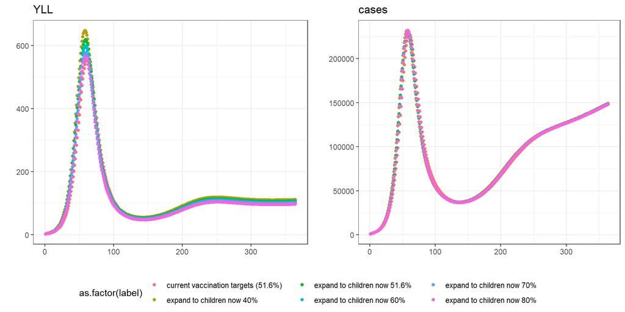

Absolute difference in outcomes (compared to current vaccine targets)

| scenario | macro_age_group | death | hosp | severe_disease | YLL | cases |
| --- | --- | --- | --- | --- | --- | --- |
| expand to children now 40% | adults | -530 | -20,470 | -6,835 | -5,762 | -392,411 |
| expand to children now 40% | children | 6 | 3,896 | 65 | 367 | -43,522 |
| expand to children now 40% | net | -524 | -16,574 | -6,769 | -5,395 | -435,933 |
| expand to children now 51.6% | adults | -364 | -13,997 | -4,678 | -3,947 | -319,616 |
| expand to children now 51.6% | children | 13 | 7,792 | 129 | 741 | 20,459 |
| expand to children now 51.6% | net | -351 | -6,204 | -4,549 | -3,207 | -299,157 |
| expand to children now 60% | adults | -247 | -9,448 | -3,164 | -2,674 | -297,941 |
| expand to children now 60% | children | 17 | 10,559 | 175 | 1,005 | 38,377 |
| expand to children now 60% | net | -230 | 1,111 | -2,989 | -1,669 | -259,564 |
| expand to children now 70% | adults | -109 | -4,071 | -1,375 | -1,169 | -281,138 |
| expand to children now 70% | children | 23 | 13,837 | 229 | 1,319 | 52,090 |
| expand to children now 70% | net | -87 | 9,766 | -1,145 | 150 | -229,048 |
| expand to children now 80% | adults | -34 | -1,126 | -394 | -344 | -272,352 |
| expand to children now 80% | children | 25 | 15,633 | 259 | 1,491 | 59,388 |
| expand to children now 80% | net | -8 | 14,507 | -136 | 1,146 | -212,963 |

Relative difference in outcomes (%)

| scenario | macro_age_group | death | hosp | severe_disease | YLL | cases |
| --- | --- | --- | --- | --- | --- | --- |
| expand to children now 40% | adults | -16.12 | -15.64 | -15.70 | -16.02 | -2.03 |
| expand to children now 40% | children | 4.45 | 4.70 | 5.42 | 4.22 | -0.32 |
| expand to children now 40% | net | -15.27 | -7.76 | -15.13 | -12.08 | -1.32 |
| expand to children now 51.6% | adults | -11.05 | -10.70 | -10.75 | -10.97 | -1.66 |
| expand to children now 51.6% | children | 8.93 | 9.41 | 10.73 | 8.51 | 0.15 |
| expand to children now 51.6% | net | -10.23 | -2.90 | -10.17 | -7.18 | -0.91 |
| expand to children now 60% | adults | -7.51 | -7.22 | -7.27 | -7.43 | -1.54 |
| expand to children now 60% | children | 12.11 | 12.75 | 14.52 | 11.55 | 0.28 |
| expand to children now 60% | net | -6.70 | 0.52 | -6.68 | -3.74 | -0.79 |
| expand to children now 70% | adults | -3.32 | -3.11 | -3.16 | -3.25 | -1.46 |
| expand to children now 70% | children | 15.88 | 16.71 | 19.00 | 15.16 | 0.38 |
| expand to children now 70% | net | -2.52 | 4.57 | -2.56 | 0.34 | -0.69 |
| expand to children now 80% | adults | -1.02 | -0.86 | -0.91 | -0.96 | -1.41 |
| expand to children now 80% | children | 17.95 | 18.88 | 21.46 | 17.13 | 0.43 |
| expand to children now 80% | net | -0.24 | 6.79 | -0.30 | 2.57 | -0.65 |

# 4 Varying speed of vaccine roll-out

This section models varying speeds of vaccine roll-out *DURING* an outbreak.

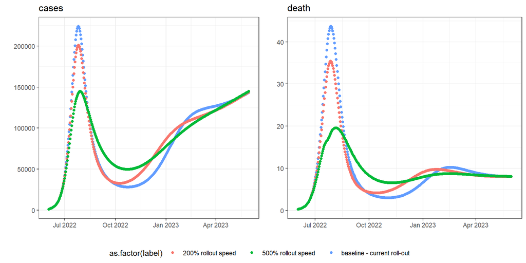

Absolute difference in outcomes (compared to current rollout speed)

| scenario | death | hosp | severe_disease | YLL | cases |
| --- | --- | --- | --- | --- | --- |
| 200% rollout speed | 132 | 4,337 | 1,588 | 1,366 | -429,843 |
| 500% rollout speed | 273 | 10,533 | 3,560 | 3,008 | -483,451 |

Relative difference in outcomes (%)

| scenario | death | hosp | severe_disease | YLL | cases |
| --- | --- | --- | --- | --- | --- |
| 200% rollout speed | 3.71 | 1.98 | 3.40 | 2.96 | -1.38 |
| 500% rollout speed | 7.70 | 4.80 | 7.63 | 6.52 | -1.55 |